# CAMPANHAS JUNHO 2022

13 julho, 2022

### TOTAL DE BONIFICAÇÕES EM JUNHO 2022: 40.078

Esse documento é uma análise visual da atividade de campanhas com bonificação em cartões Alelo.

Diferente do mês anterior, a bonificação em rebates teve uma participação maior que as Insigne no total de bonificações, porém as bonificações Insigne foram menores que os rebates devido à regra de não bonificar pedidos digitados. Novas campanhas Varilux também foram adicionadas.

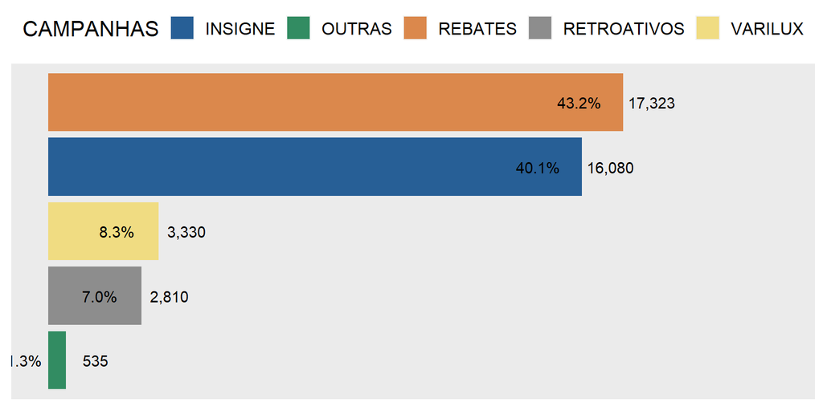

As bonificações Insigne tiveram uma queda nos últimos 3 meses.

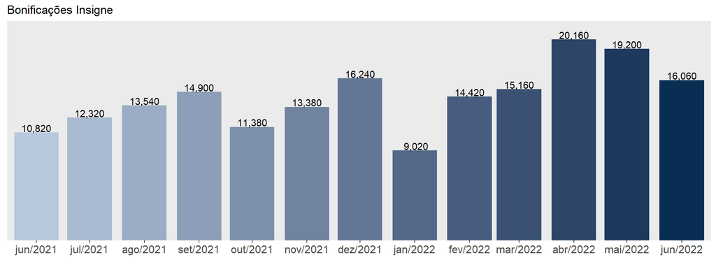

No comparativo com as vendas de lentes Insigne deste ano, houve uma queda nas vendas de -1,90% e nas bonificações -16% porém uma vez que não foram bonificados R$2500 por serem pedidos digitados a variação em bonificações seria -3%.

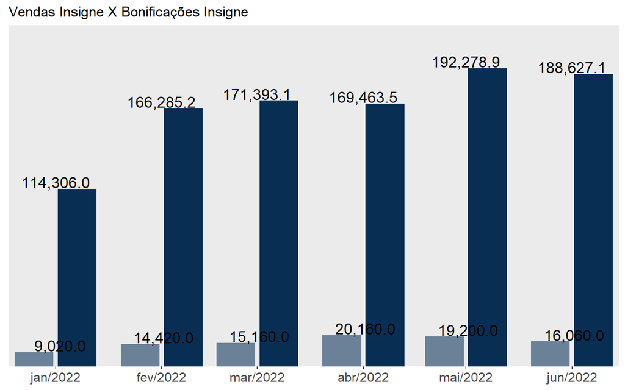

As bonificações em rebates tiveram uma pequena variação positiva em Junho e estão concentradas em 3 clientes: Schroeder (setor5), Vital(setor2) e Dom Bosco(setor 3). Rebates estão correlacionados com o faturamento.

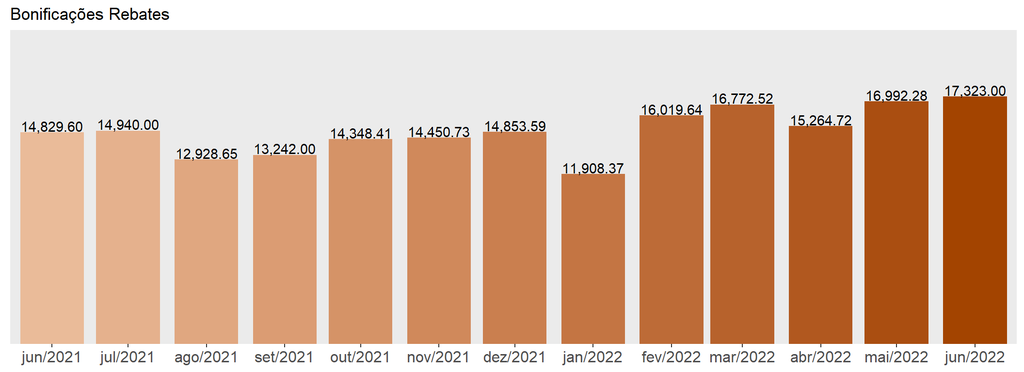

As ofertas de campanhas Varilux cresceram nos últimos 3 meses. Em junho 8 clientes foram bonificadas.

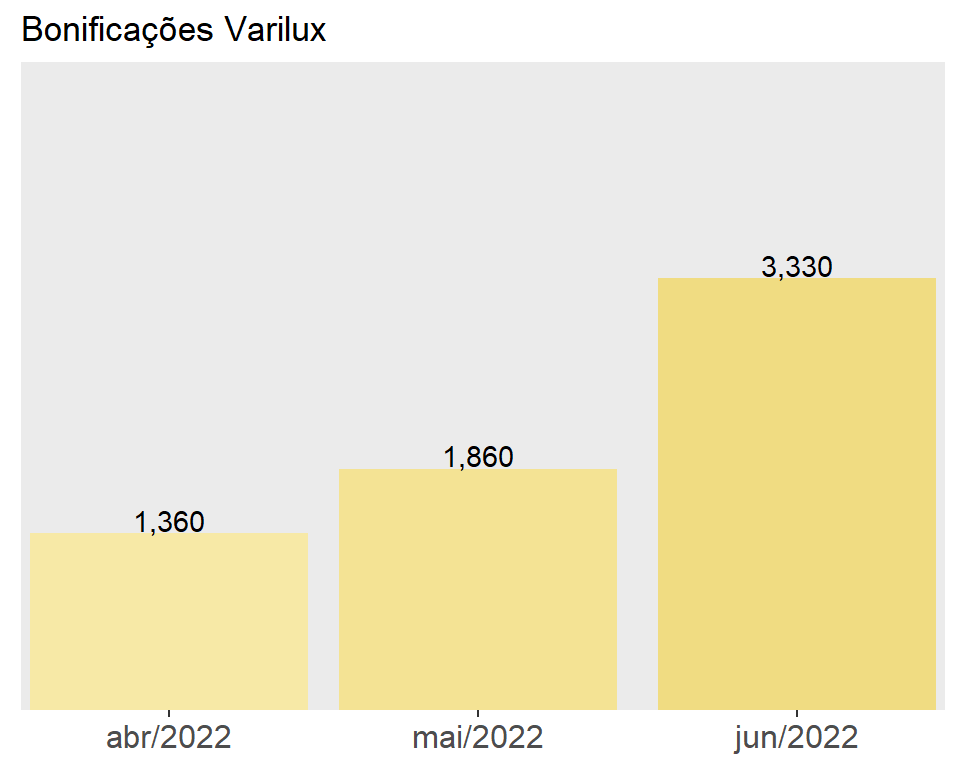

Campanhas pontuais com outros produtos caíram em Junho. Com um valor tão baixo a recomendação é que sejam encerradas.

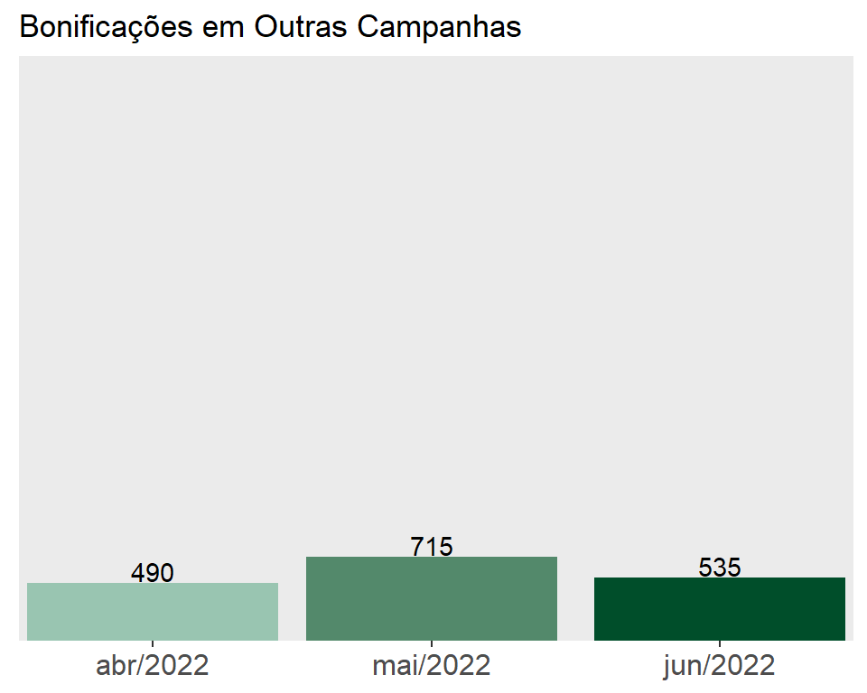

Após uma alta no mês anterior devido às correções, as bonificações retroativas caíram em Junho. Apenas 3 participantes precisaram ser bonificados retroativamente.

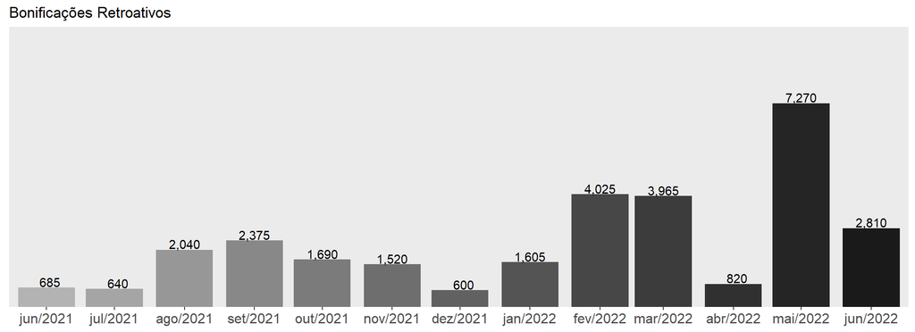